# IP_Week_14_PartB

Farnadis_Kanja

2/5/2022

Let’s begin by installing dependencies and their libraries

```r
install.packages("data.table") # install package data.table to work with data tables
library("data.table")
```

```r
install.packages("tidyverse") # install packages to work with data frame - extends into visualization
library(tidyverse)
```

Let’s load the dataset and preview it

```r
online_shoppers <- fread('http://bit.ly/EcommerceCustomersDataset')
head(online_shoppers)
```

```
##    Administrative Administrative_Duration Informational Informational_Duration
## 1:              0                       0             0                      0
## 2:              0                       0             0                      0
## 3:              0                      -1             0                     -1
## 4:              0                       0             0                      0
## 5:              0                       0             0                      0
## 6:              0                       0             0                      0
##    ProductRelated ProductRelated_Duration BounceRates ExitRates PageValues
## 1:              1                0.000000  0.20000000 0.2000000          0
## 2:              2               64.000000  0.00000000 0.1000000          0
## 3:              1               -1.000000  0.20000000 0.2000000          0
## 4:              2                2.666667  0.05000000 0.1400000          0
## 5:             10              627.500000  0.02000000 0.0500000          0
## 6:             19              154.216667  0.01578947 0.0245614          0
##    SpecialDay Month OperatingSystems Browser Region TrafficType
## 1:          0   Feb                1       1      1           1
## 2:          0   Feb                2       2      1           2
## 3:          0   Feb                4       1      9           3
## 4:          0   Feb                3       2      2           4
## 5:          0   Feb                3       3      1           4
## 6:          0   Feb                2       2      1           3
##          VisitorType Weekend Revenue
## 1: Returning_Visitor   FALSE   FALSE
## 2: Returning_Visitor   FALSE   FALSE
## 3: Returning_Visitor   FALSE   FALSE
## 4: Returning_Visitor   FALSE   FALSE
## 5: Returning_Visitor    TRUE   FALSE
## 6: Returning_Visitor   FALSE   FALSE
```

Let us look at the various properties of the dataset Let’s look at the data types

```r
sapply(online_shoppers,class)
```

```
##          Administrative Administrative_Duration           Informational
##               "integer"               "numeric"               "integer"
##  Informational_Duration          ProductRelated ProductRelated_Duration
##               "numeric"               "integer"               "numeric"
##             BounceRates               ExitRates              PageValues
##               "numeric"               "numeric"               "numeric"
##              SpecialDay                   Month        OperatingSystems
##               "numeric"             "character"               "integer"
##                 Browser                  Region             TrafficType
##               "integer"               "integer"               "integer"
##             VisitorType                 Weekend                 Revenue
##             "character"               "logical"               "logical"
```

To get a better understanding of the data

```r
str(online_shoppers)
```

```
## Classes 'data.table' and 'data.frame':   12330 obs. of  18 variables:
##  $ Administrative         : int  0 0 0 0 0 0 0 1 0 0 ...
##  $ Administrative_Duration: num  0 0 -1 0 0 0 -1 -1 0 0 ...
##  $ Informational          : int  0 0 0 0 0 0 0 0 0 0 ...
##  $ Informational_Duration : num  0 0 -1 0 0 0 -1 -1 0 0 ...
##  $ ProductRelated         : int  1 2 1 2 10 19 1 1 2 3 ...
##  $ ProductRelated_Duration: num  0 64 -1 2.67 627.5 ...
##  $ BounceRates            : num  0.2 0 0.2 0.05 0.02 ...
##  $ ExitRates              : num  0.2 0.1 0.2 0.14 0.05 ...
##  $ PageValues             : num  0 0 0 0 0 0 0 0 0 0 ...
##  $ SpecialDay             : num  0 0 0 0 0 0 0.4 0 0.8 0.4 ...
##  $ Month                  : chr  "Feb" "Feb" "Feb" "Feb" ...
##  $ OperatingSystems       : int  1 2 4 3 3 2 2 1 2 2 ...
##  $ Browser                : int  1 2 1 2 3 2 4 2 2 4 ...
##  $ Region                 : int  1 1 9 2 1 1 3 1 2 1 ...
##  $ TrafficType            : int  1 2 3 4 4 3 3 5 3 2 ...
##  $ VisitorType            : chr  "Returning_Visitor" "Returning_Visitor" "Returning_Visitor" "Returning_Visitor" ...
##  $ Weekend                : logi  FALSE FALSE FALSE FALSE TRUE FALSE ...
##  $ Revenue                : logi  FALSE FALSE FALSE FALSE FALSE FALSE ...
##  - attr(*, ".internal.selfref")=<externalptr>
```

To get dimensions of our dataset

```r
dim(online_shoppers)
```

```
## [1] 12330    18
```

```r
#the dataset has 12330 observations(rows) and 18 variables(columns)
```

```r
class(online_shoppers)
```

```
## [1] "data.table" "data.frame"
```

Data Cleaning Let’s begin by checking for null values in our dataset

```r
is.na(online_shoppers)
```

[output not shown]

[output cut: 22210 more lines]

Let’s check for null values column by column

```r
colSums(is.na(online_shoppers))
```

```
##          Administrative Administrative_Duration           Informational
##                      14                      14                      14
##  Informational_Duration          ProductRelated ProductRelated_Duration
##                      14                      14                      14
##             BounceRates               ExitRates              PageValues
##                      14                      14                       0
##              SpecialDay                   Month        OperatingSystems
##                       0                       0                       0
##                 Browser                  Region             TrafficType
##                       0                       0                       0
##             VisitorType                 Weekend                 Revenue
##                       0                       0                       0
```

Let’s drop all the null values

```r
library(dplyr)
online_shoppers_new <-online_shoppers %>%
na.omit()
dim(online_shoppers_new)
```

```
## [1] 12316    18
```

```r
#our new dataset has 12316 observations and 18 variables which means it has not been affected that much.
```

Let’s look at duplicates

```r
duplicated_rows <- online_shoppers_new[duplicated(online_shoppers_new),]
duplicated_rows
```

```
##      Administrative Administrative_Duration Informational
##   1:              0                       0             0
##   2:              0                       0             0
##   3:              0                       0             0
##   4:              0                       0             0
##   5:              0                       0             0
##  ---
## 113:              0                       0             0
## 114:              0                       0             0
## 115:              0                       0             0
## 116:              0                       0             0
## 117:              0                       0             0
##      Informational_Duration ProductRelated ProductRelated_Duration BounceRates
##   1:                      0              1                       0         0.2
##   2:                      0              1                       0         0.2
```

[output cut: 33 more lines]

We need to eliminate the duplicated rows

```r
new_df <- online_shoppers_new[!duplicated(online_shoppers_new), ]
head(new_df)
```

```
##    Administrative Administrative_Duration Informational Informational_Duration
## 1:              0                       0             0                      0
## 2:              0                       0             0                      0
## 3:              0                      -1             0                     -1
## 4:              0                       0             0                      0
## 5:              0                       0             0                      0
## 6:              0                       0             0                      0
##    ProductRelated ProductRelated_Duration BounceRates ExitRates PageValues
## 1:              1                0.000000  0.20000000 0.2000000          0
## 2:              2               64.000000  0.00000000 0.1000000          0
## 3:              1               -1.000000  0.20000000 0.2000000          0
## 4:              2                2.666667  0.05000000 0.1400000          0
## 5:             10              627.500000  0.02000000 0.0500000          0
## 6:             19              154.216667  0.01578947 0.0245614          0
##    SpecialDay Month OperatingSystems Browser Region TrafficType
## 1:          0   Feb                1       1      1           1
## 2:          0   Feb                2       2      1           2
## 3:          0   Feb                4       1      9           3
## 4:          0   Feb                3       2      2           4
## 5:          0   Feb                3       3      1           4
## 6:          0   Feb                2       2      1           3
##          VisitorType Weekend Revenue
## 1: Returning_Visitor   FALSE   FALSE
## 2: Returning_Visitor   FALSE   FALSE
## 3: Returning_Visitor   FALSE   FALSE
## 4: Returning_Visitor   FALSE   FALSE
## 5: Returning_Visitor    TRUE   FALSE
## 6: Returning_Visitor   FALSE   FALSE
```

```r
sapply(new_df,class)
```

```
##          Administrative Administrative_Duration           Informational
##               "integer"               "numeric"               "integer"
##  Informational_Duration          ProductRelated ProductRelated_Duration
##               "numeric"               "integer"               "numeric"
##             BounceRates               ExitRates              PageValues
##               "numeric"               "numeric"               "numeric"
##              SpecialDay                   Month        OperatingSystems
##               "numeric"             "character"               "integer"
##                 Browser                  Region             TrafficType
##               "integer"               "integer"               "integer"
##             VisitorType                 Weekend                 Revenue
##             "character"               "logical"               "logical"
```

Let’s check the dimensions of the our new dataset

```r
dim(new_df)
```

```
## [1] 12199    18
```

```r
#our new dataset now has 12199 observations and 18 variables
```

look at our new dataset

```r
head(new_df)
```

```
##    Administrative Administrative_Duration Informational Informational_Duration
## 1:              0                       0             0                      0
## 2:              0                       0             0                      0
## 3:              0                      -1             0                     -1
## 4:              0                       0             0                      0
## 5:              0                       0             0                      0
## 6:              0                       0             0                      0
##    ProductRelated ProductRelated_Duration BounceRates ExitRates PageValues
## 1:              1                0.000000  0.20000000 0.2000000          0
## 2:              2               64.000000  0.00000000 0.1000000          0
## 3:              1               -1.000000  0.20000000 0.2000000          0
## 4:              2                2.666667  0.05000000 0.1400000          0
## 5:             10              627.500000  0.02000000 0.0500000          0
## 6:             19              154.216667  0.01578947 0.0245614          0
##    SpecialDay Month OperatingSystems Browser Region TrafficType
## 1:          0   Feb                1       1      1           1
## 2:          0   Feb                2       2      1           2
## 3:          0   Feb                4       1      9           3
## 4:          0   Feb                3       2      2           4
## 5:          0   Feb                3       3      1           4
## 6:          0   Feb                2       2      1           3
##          VisitorType Weekend Revenue
## 1: Returning_Visitor   FALSE   FALSE
## 2: Returning_Visitor   FALSE   FALSE
## 3: Returning_Visitor   FALSE   FALSE
## 4: Returning_Visitor   FALSE   FALSE
## 5: Returning_Visitor    TRUE   FALSE
## 6: Returning_Visitor   FALSE   FALSE
```

```r
df3 <- subset(new_df, select = c ('ProductRelated_Duration', 'BounceRates', 'ExitRates', 'Administrative', 'ProductRelated', 'Administrative_Duration', 'Informational', 'Informational_Duration', 'PageValues', 'SpecialDay'))
```

```r
names(df3)[names(df3) == "ProductRelated_Duration"] <- "prod_dur"
names(df3)[names(df3) == "Administrative"] <- "admin"
names(df3)[names(df3) == "Administrative_Duration"] <- "admin_dur"
names(df3)[names(df3) == "Informational_Duration"] <- "info_dur"
```

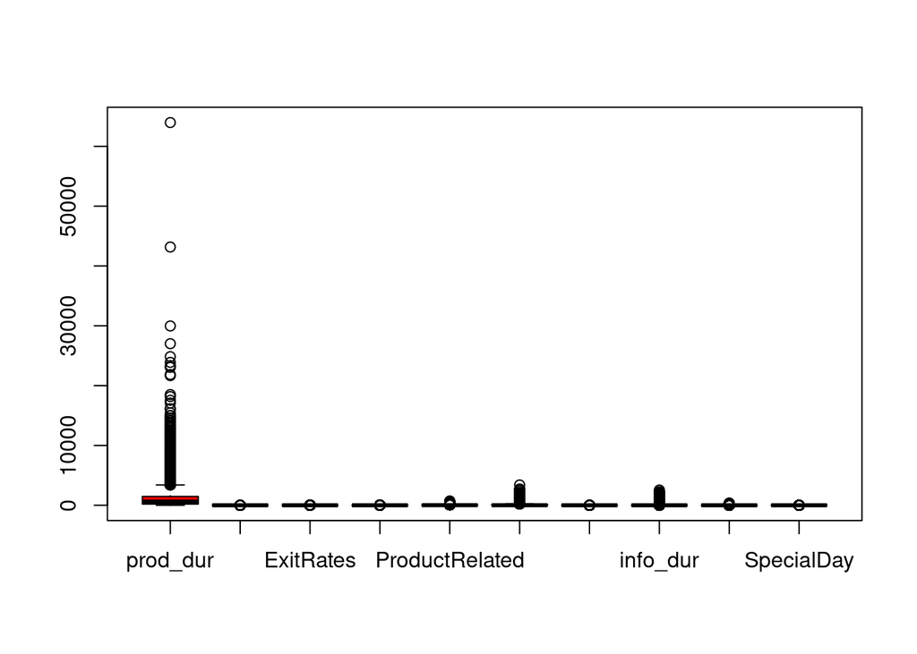

```r
boxplot(df3, col = rainbow(ncol(df3)))
```

```r
#product related information has a few outliers which we will not eliminate since it could have an impact on the decision the shopper makes
```

```r
summary(df3)
```

```
##     prod_dur        BounceRates        ExitRates           admin
##  Min.   :   -1.0   Min.   :0.00000   Min.   :0.00000   Min.   : 0.00
##  1st Qu.:  193.6   1st Qu.:0.00000   1st Qu.:0.01422   1st Qu.: 0.00
##  Median :  609.5   Median :0.00293   Median :0.02500   Median : 1.00
##  Mean   : 1207.5   Mean   :0.02045   Mean   :0.04150   Mean   : 2.34
##  3rd Qu.: 1477.6   3rd Qu.:0.01667   3rd Qu.:0.04848   3rd Qu.: 4.00
##  Max.   :63973.5   Max.   :0.20000   Max.   :0.20000   Max.   :27.00
##  ProductRelated     admin_dur       Informational        info_dur
##  Min.   :  0.00   Min.   :  -1.00   Min.   : 0.0000   Min.   :  -1.00
##  1st Qu.:  8.00   1st Qu.:   0.00   1st Qu.: 0.0000   1st Qu.:   0.00
##  Median : 18.00   Median :   9.00   Median : 0.0000   Median :   0.00
##  Mean   : 32.06   Mean   :  81.68   Mean   : 0.5088   Mean   :  34.84
##  3rd Qu.: 38.00   3rd Qu.:  94.75   3rd Qu.: 0.0000   3rd Qu.:   0.00
##  Max.   :705.00   Max.   :3398.75   Max.   :24.0000   Max.   :2549.38
##    PageValues        SpecialDay
##  Min.   :  0.000   Min.   :0.00000
##  1st Qu.:  0.000   1st Qu.:0.00000
##  Median :  0.000   Median :0.00000
##  Mean   :  5.952   Mean   :0.06197
##  3rd Qu.:  0.000   3rd Qu.:0.00000
##  Max.   :361.764   Max.   :1.00000
```

The following conclusions can be made at this point; The mean of product related duration is 1207.5 while the median is 609.5 The mean of bounce rates is 0.02 and the median is 0.003(rounded off) The mean of the exit rates stands at 0.04 abd the median is not too far off at 0.03(rounded off) The mean of ProductRelated is 32 while the median is 18 The mean of administrative duration is 81.68 and the median is 9 The mean of special day is 0.06 while the median is 0 The mean of informational is 0.5 but the media is 0 The mean of informational duration is 34.84 but the median is 0 Let’s determine the mode

```r
getmode <- function(v) {
  uniqv <- unique(v)
  uniqv[which.max(tabulate(match(v, uniqv)))]
}
```

Bounce Rate Mode

```r
bounce_rate_mode<- getmode(df3$BounceRates)
bounce_rate_mode
```

```
## [1] 0
```

```r
#people were not leaving the site, that's interesting.
```

Product Related Duration

```r
Product_related_mode<- getmode(df3$prod_dur)
Product_related_mode
```

```
## [1] 0
```

Exit Rates

```r
ExitRatesMode<- getmode(df3$ExitRates)
ExitRatesMode
```

```
## [1] 0.2
```

Admin

```r
Administrative_mode<- getmode(df3$admin)
Administrative_mode
```

```
## [1] 0
```

Product Related

```r
Prod_related_mode<- getmode(df3$ProductRelated)
Prod_related_mode
```

```
## [1] 1
```

The Standard deviations for all the numeric variables

```r
library(dplyr)
df3 %>% summarise_if(is.numeric, sd)
```

```
##   prod_dur BounceRates  ExitRates    admin ProductRelated admin_dur
## 1 1919.927   0.0454025 0.04624716 3.330851       44.60091  177.5282
##   Informational info_dur PageValues SpecialDay
## 1      1.275817 141.4585   18.65779  0.1997106
```

```r
#many of the variables have very huge standard deviations signifying large movements from the mean
```

The Variance for all the numeric variables

```r
library(dplyr)
df3 %>% summarise_if(is.numeric, var)
```

```
##   prod_dur BounceRates ExitRates    admin ProductRelated admin_dur
## 1  3686121 0.002061387 0.0021388 11.09457       1989.241  31516.25
##   Informational info_dur PageValues SpecialDay
## 1       1.62771 20010.51   348.1132 0.03988432
```

Let’s look at the categorical data Region

```r
require(dplyr)

n_distinct(new_df$Region)
```

```
## [1] 9
```

```r
#there are 9 distinct regions in the dataset
```

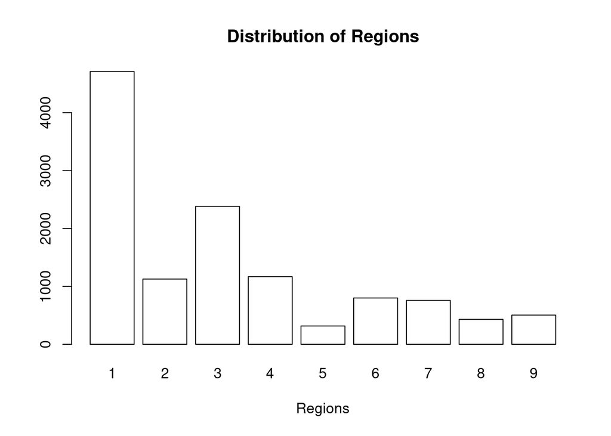

```r
region <- table(new_df$Region)
barplot(region, main="Distribution of Regions", col=c(rainbow),xlab="Regions")
```

```r
#1 is the most popular region in the dataset
```

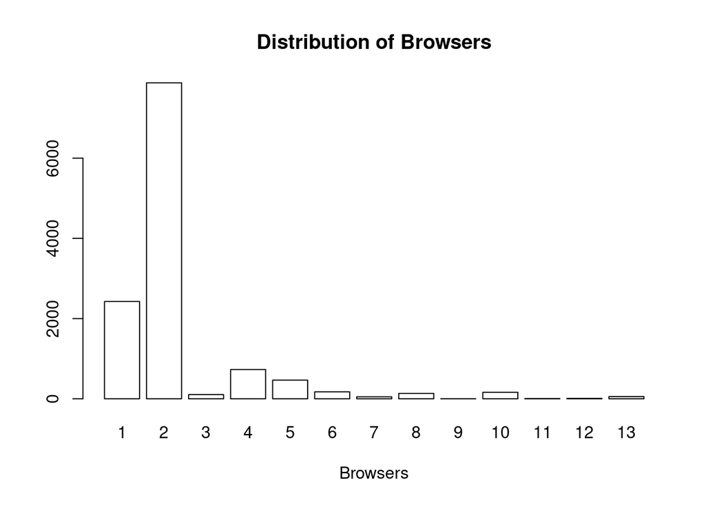

```r
browser <- table(new_df$Browser)
barplot(browser, main="Distribution of Browsers", col=c(rainbow),xlab="Browsers")
```

```r
#2 is the most preferred browser
```

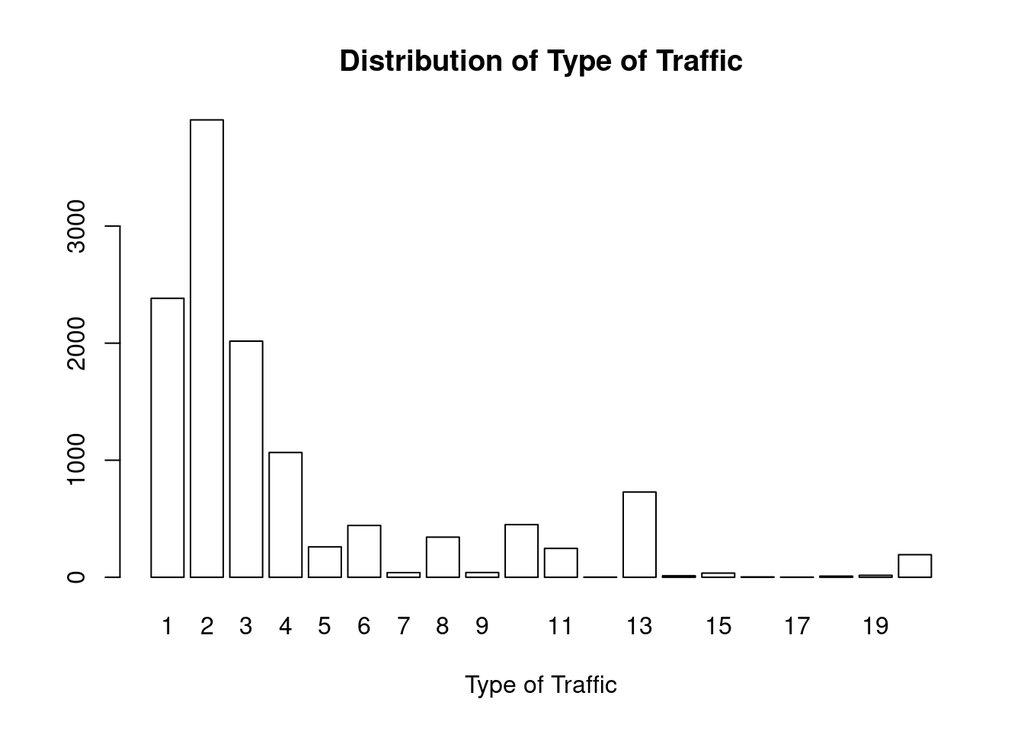

```r
traffictype <- table(new_df$TrafficType)
barplot(traffictype, main="Distribution of Type of Traffic", col=c(rainbow),xlab="Type of Traffic")
```

```r
#2 is the most most popular type of traffic
```

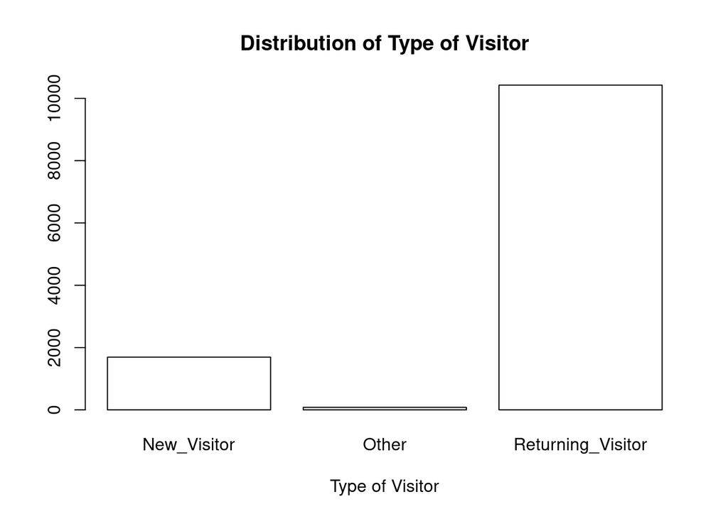

```r
visitorType <- table(new_df$VisitorType)
barplot(visitorType, main="Distribution of Type of Visitor", col=c(rainbow),xlab="Type of Visitor")
```

```r
#A returning visitor is the most popuar visitor
```

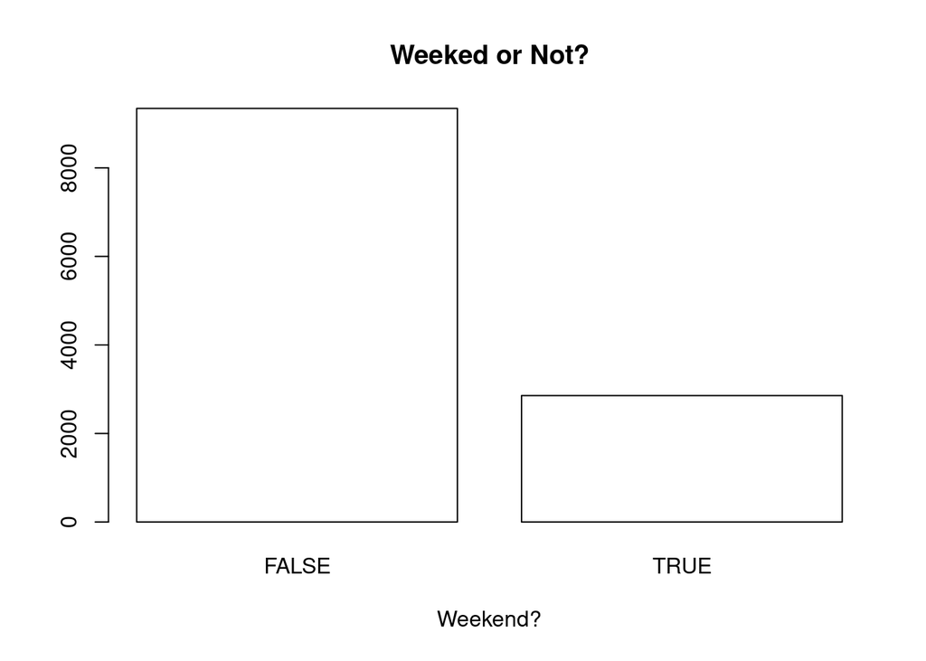

```r
weekend_or_not <- table(new_df$Weekend)
barplot(weekend_or_not, main="Weeked or Not?", col=c(rainbow),xlab="Weekend?")
```

```r
#most people were on the website during the week day
```